# KCell

## Boolean shapes

If you want to subtract one shape from another, merge two shapes, or perform an XOR on them, you can do that with the `boolean()` function.

The `operation` argument should be {not, and, or, xor, 'A-B', 'B-A', 'A+B'}. Note that 'A+B' is equivalent to 'or', 'A-B' is equivalent to 'not', and 'B-A' is equivalent to 'not' with the operands switched.

```python
e1 = kf.kdb.DPolygon.ellipse(kf.kdb.DBox(10, 8), 64)
e2 = kf.kdb.DPolygon.ellipse(kf.kdb.DBox(10, 6), 64).transformed(
    kf.kdb.DTrans(2.0, 0.0)
)
```

e1 = kf.kdb.DPolygon.ellipse(kf.kdb.DBox(10, 8), 64) e2 = kf.kdb.DPolygon.ellipse(kf.kdb.DBox(10, 6), 64).transformed( kf.kdb.DTrans(2.0, 0.0) )

```python
c = kf.KCell()
c.shapes(c.kcl.find_layer(2, 0)).insert(e1)
c.shapes(c.kcl.find_layer(4, 0)).insert(e2)
c
```

c = kf.KCell() c.shapes(c.kcl.find_layer(2, 0)).insert(e1) c.shapes(c.kcl.find_layer(4, 0)).insert(e2) c

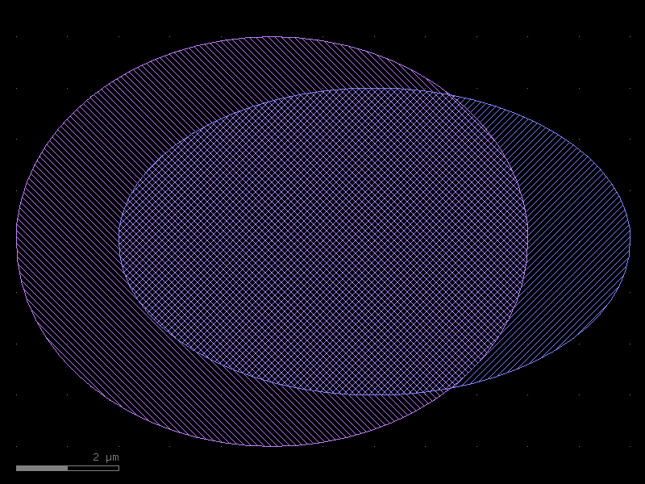

```python
# e1 NOT e2
c = kf.KCell()
e3 = kf.kdb.Region(c.kcl.to_dbu(e1)) - kf.kdb.Region(c.kcl.to_dbu(e2))
c.shapes(c.kcl.find_layer(1, 0)).insert(e3)
c
```

# e1 NOT e2 c = kf.KCell() e3 = kf.kdb.Region(c.kcl.to_dbu(e1)) - kf.kdb.Region(c.kcl.to_dbu(e2)) c.shapes(c.kcl.find_layer(1, 0)).insert(e3) c

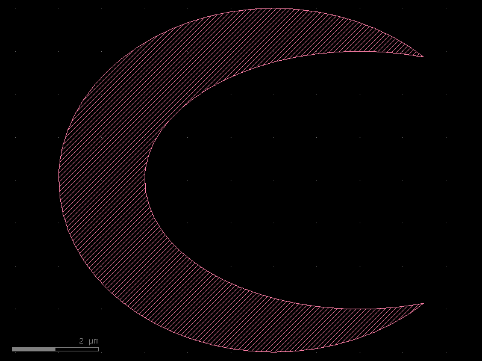

```python
# e1 AND e2
c = kf.KCell()
e3 = kf.kdb.Region(c.kcl.to_dbu(e1)) & kf.kdb.Region(c.kcl.to_dbu(e2))
c.shapes(c.kcl.find_layer(1, 0)).insert(e3)
c
```

# e1 AND e2 c = kf.KCell() e3 = kf.kdb.Region(c.kcl.to_dbu(e1)) & kf.kdb.Region(c.kcl.to_dbu(e2)) c.shapes(c.kcl.find_layer(1, 0)).insert(e3) c

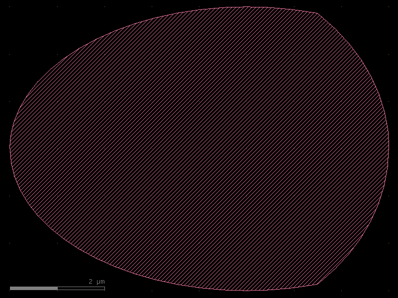

```python
# e1 OR e2
c = kf.KCell()
e3 = kf.kdb.Region(c.kcl.to_dbu(e1)) + kf.kdb.Region(c.kcl.to_dbu(e2))
c.shapes(c.kcl.find_layer(1, 0)).insert(e3)
c
```

# e1 OR e2 c = kf.KCell() e3 = kf.kdb.Region(c.kcl.to_dbu(e1)) + kf.kdb.Region(c.kcl.to_dbu(e2)) c.shapes(c.kcl.find_layer(1, 0)).insert(e3) c

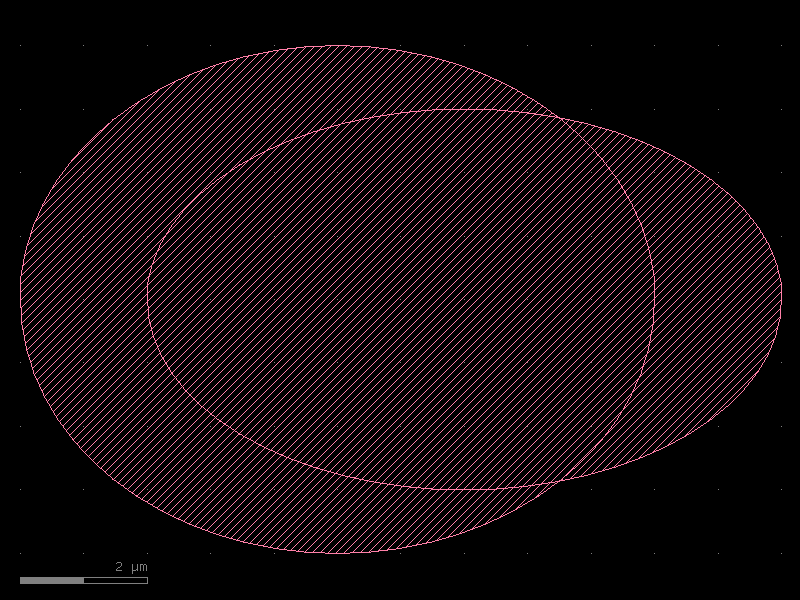

```python
# e1 OR e2 (merged)
c = kf.KCell()
e3 = (
    kf.kdb.Region(c.kcl.to_dbu(e1)) + kf.kdb.Region(c.kcl.to_dbu(e2))
).merge()
c.shapes(c.kcl.find_layer(1, 0)).insert(e3)
c
```

# e1 OR e2 (merged) c = kf.KCell() e3 = ( kf.kdb.Region(c.kcl.to_dbu(e1)) + kf.kdb.Region(c.kcl.to_dbu(e2)) ).merge() c.shapes(c.kcl.find_layer(1, 0)).insert(e3) c

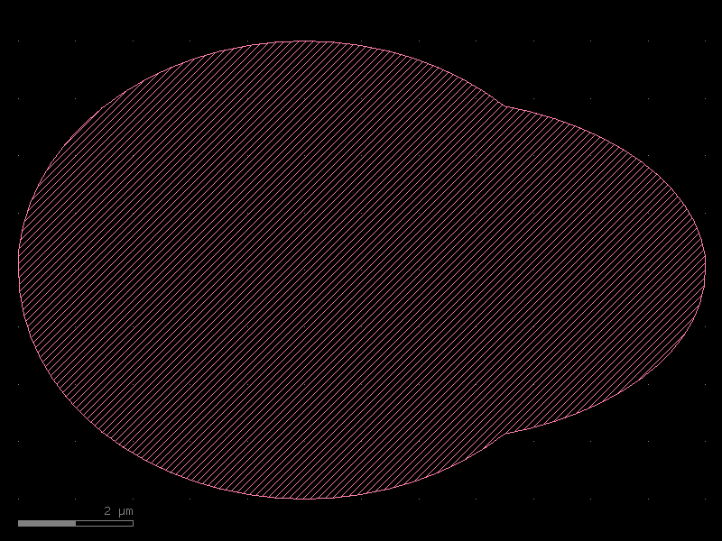

```python
# e1 XOR e2
c = kf.KCell()
e3 = kf.kdb.Region(c.kcl.to_dbu(e1)) ^ kf.kdb.Region(c.kcl.to_dbu(e2))
c.shapes(c.kcl.find_layer(1, 0)).insert(e3)
c
```

# e1 XOR e2 c = kf.KCell() e3 = kf.kdb.Region(c.kcl.to_dbu(e1)) ^ kf.kdb.Region(c.kcl.to_dbu(e2)) c.shapes(c.kcl.find_layer(1, 0)).insert(e3) c

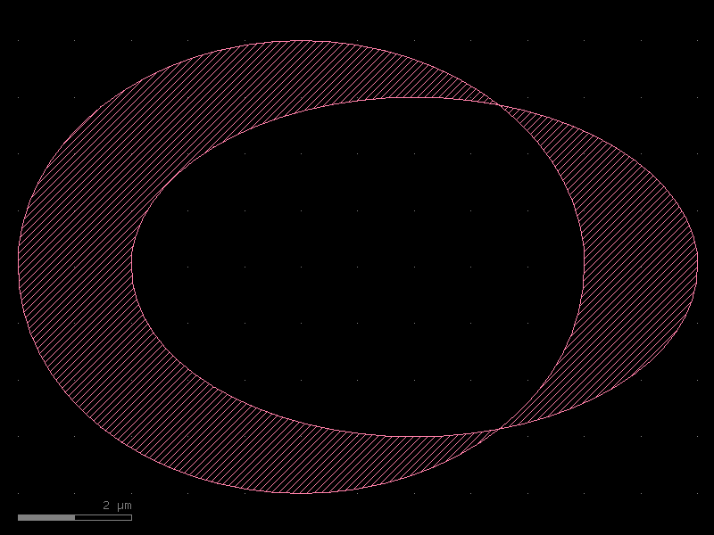

## Move the instance by port

```python
c = kf.KCell()
wg = c << kf.cells.straight.straight(width=0.5, length=1, layer=LAYER.WG)
bend = c << kf.cells.euler.bend_euler(width=0.5, radius=1, layer=LAYER.WG)

bend.connect("o1", wg.ports["o2"])  # connects follow source, the destination is the syntax
c
```

c = kf.KCell() wg = c << kf.cells.straight.straight(width=0.5, length=1, layer=LAYER.WG) bend = c << kf.cells.euler.bend_euler(width=0.5, radius=1, layer=LAYER.WG) bend.connect("o1", wg.ports["o2"]) # connects follow source, the destination is the syntax c

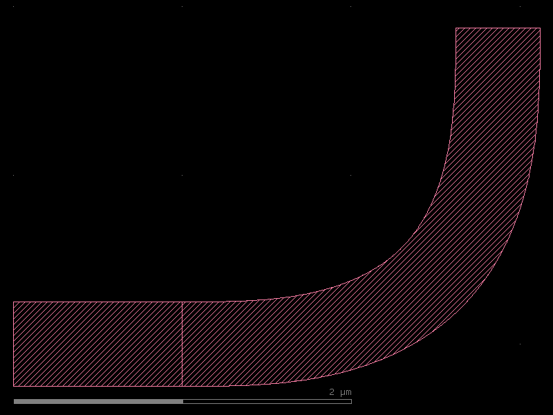

## Rotate instance

You can rotate in degrees using `Instance.drotate` or in multiples of 90 deg.

```python
c = kf.KCell(name="mirror_example3")
bend = kf.cells.euler.bend_euler(width=0.5, radius=1, layer=LAYER.WG)
b1 = c << bend
b2 = c << bend
b2.drotate(90)
c
```

c = kf.KCell(name="mirror_example3") bend = kf.cells.euler.bend_euler(width=0.5, radius=1, layer=LAYER.WG) b1 = c << bend b2 = c << bend b2.drotate(90) c

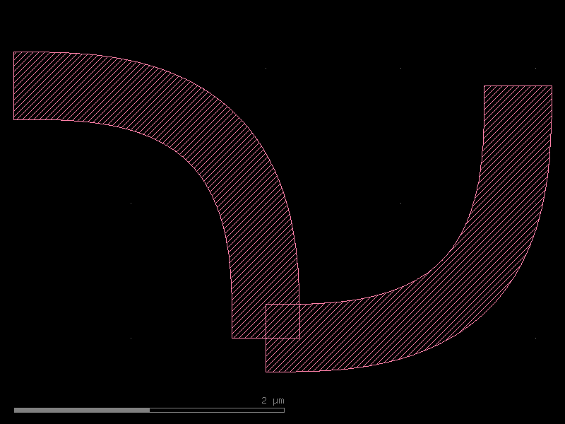

```python
c = kf.KCell(name="mirror_example4")
bend = kf.cells.euler.bend_euler(width=0.5, radius=1, layer=LAYER.WG)
b1 = c << bend
b2 = c << bend
b2.rotate(1)
c
```

c = kf.KCell(name="mirror_example4") bend = kf.cells.euler.bend_euler(width=0.5, radius=1, layer=LAYER.WG) b1 = c << bend b2 = c << bend b2.rotate(1) c

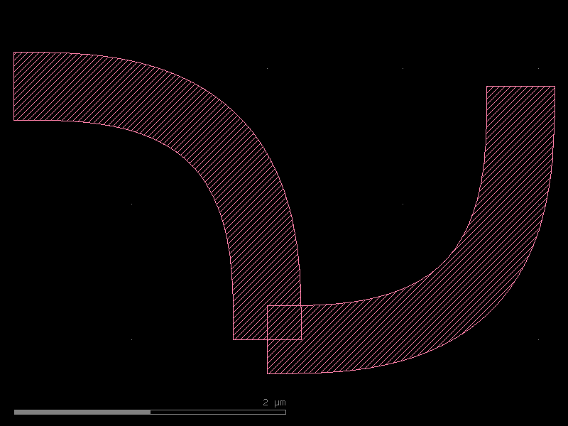

## Write GDS

GDSII is the standard format for exchanging CMOS circuits with foundries

You can write your cell to a GDS file.

```python
c.write("demo.gds")
```

c.write("demo.gds")